# Week 2

## Classification of digits

- Machine learning
- Google Quick Draw
- Solving quadratic equations - machine learning vs. non-machine learning approach.
- The k-NN algorithm
- The MNIST database

## Accessing MNIST data

- Download image and labels files from the MNIST project page, place in the directory with the notebook.

```python
ls
```

```
train-images-idx3-ubyte.gz  week_2_class.ipynb
train-labels-idx1-ubyte.gz  week_2_prep.ipynb
```

```python
import gzip
```

```python
with gzip.open("train-images-idx3-ubyte.gz", 'rb') as foo:
    f = foo.read()
```

```python
f[:20]
```

```
b'\x00\x00\x08\x03\x00\x00\xea`\x00\x00\x00\x1c\x00\x00\x00\x1c\x00\x00\x00\x00'
```

```python
b'\xf0'[0]
```

```
240
```

```python
ord('`')
```

```
96
```

```python
[b for b in f[:20]]
```

```
[0, 0, 8, 3, 0, 0, 234, 96, 0, 0, 0, 28, 0, 0, 0, 28, 0, 0, 0, 0]
```

- Check the description of the file format from the website with MNIST data. We can ignore the first 16 bytes. The rest consists of images 28x28 pixels each. The color of each pixel is specified by one byte.

```python
import numpy as np
images = np.array([b for b in f[16:]]).reshape(-1, 28*28)
```

```python
img = images[90].reshape(28,28)
img
```

```
array([[  0,   0,   0,   0,   0,   0,   0,   0,   0,   0,   0,   0,   0,
          0,   0,   0,   0,   0,   0,   0,   0,   0,   0,   0,   0,   0,
          0,   0],
       [  0,   0,   0,   0,   0,   0,   0,   0,   0,   0,   0,   0,   0,
          0,   0,   0,   0,   0,   0,   0,   0,   0,   0,   0,   0,   0,
          0,   0],
       [  0,   0,   0,   0,   0,   0,   0,   0,   0,   0,   0,   0,   0,
          0,   0,   0,   0,  25, 214, 225,  90,   0,   0,   0,   0,   0,
          0,   0],
       [  0,   0,   0,   0,   0,   0,   0,   0,   0,   0,   0,   0,   0,
          0,   0,   7, 145, 212, 253, 253,  60,   0,   0,   0,   0,   0,
          0,   0],
       [  0,   0,   0,   0,   0,   0,   0,   0,   0,   0,   0,   0,   0,
          0,   0, 106, 253, 253, 246, 188,  23,   0,   0,   0,   0,   0,
          0,   0],
       [  0,   0,   0,   0,   0,   0,   0,   0,   0,   0,   0,   0,   0,
         45, 164, 254, 253, 223, 108,   0,   0,   0,   0,   0,   0,   0,
          0,   0],
       [  0,   0,   0,   0,   0,   0,   0,   0,   0,   0,   0,   0,  24,
        236, 253, 252, 124,  28,   0,   0,   0,   0,   0,   0,   0,   0,
          0,   0],
       [  0,   0,   0,   0,   0,   0,   0,   0,   0,   0,   0, 100, 217,
        253, 218, 116,   0,   0,   0,   0,   0,   0,   0,   0,   0,   0,
          0,   0],
       [  0,   0,   0,   0,   0,   0,   0,   0,   0,   0, 158, 175, 225,
        253,  92,   0,   0,   0,   0,   0,   0,   0,   0,   0,   0,   0,
          0,   0],
       [  0,   0,   0,   0,   0,   0,   0,   0,   0,  24, 217, 241, 248,
        114,   2,   0,   0,   0,   0,   0,   0,   0,   0,   0,   0,   0,
          0,   0],
       [  0,   0,   0,   0,   0,   0,   0,   0,  21, 201, 253, 253, 114,
          3,   0,   0,   0,   0,   0,   0,   0,   0,   0,   0,   0,   0,
          0,   0],
       [  0,   0,   0,   0,   0,   0,   0,   0, 107, 253, 253, 213,  19,
          0,   0,   0,   0,   0,   0,   0,   0,   0,   0,   0,   0,   0,
          0,   0],
       [  0,   0,   0,   0,   0,   0,   0,   0, 170, 254, 254, 169,   0,
          0,   0,   0,   0,   2,  13, 100, 133,  89,   0,   0,   0,   0,
          0,   0],
       [  0,   0,   0,   0,   0,   0,   0,  18, 210, 253, 253, 100,   0,
```

[output cut: 29 more lines]

```
       [  0,   0,   0,   0,   0,   0,   0,   0,   0,   0,   0,   0,   0,
          0,   0,   0,   0,   0,   0,   0,   0,   0,   0,   0,   0,   0,
          0,   0],
       [  0,   0,   0,   0,   0,   0,   0,   0,   0,   0,   0,   0,   0,
          0,   0,   0,   0,   0,   0,   0,   0,   0,   0,   0,   0,   0,
          0,   0],
       [  0,   0,   0,   0,   0,   0,   0,   0,   0,   0,   0,   0,   0,
          0,   0,   0,   0,   0,   0,   0,   0,   0,   0,   0,   0,   0,
          0,   0],
       [  0,   0,   0,   0,   0,   0,   0,   0,   0,   0,   0,   0,   0,
          0,   0,   0,   0,   0,   0,   0,   0,   0,   0,   0,   0,   0,
          0,   0],
       [  0,   0,   0,   0,   0,   0,   0,   0,   0,   0,   0,   0,   0,
          0,   0,   0,   0,   0,   0,   0,   0,   0,   0,   0,   0,   0,
          0,   0]])
```

```python
with np.printoptions(linewidth=4*28 + 10):
    print(images[90].reshape(28, 28))
```

```
[[  0   0   0   0   0   0   0   0   0   0   0   0   0   0   0   0   0   0   0   0   0   0   0   0   0   0   0   0]
 [  0   0   0   0   0   0   0   0   0   0   0   0   0   0   0   0   0   0   0   0   0   0   0   0   0   0   0   0]
 [  0   0   0   0   0   0   0   0   0   0   0   0   0   0   0   0   0  25 214 225  90   0   0   0   0   0   0   0]
 [  0   0   0   0   0   0   0   0   0   0   0   0   0   0   0   7 145 212 253 253  60   0   0   0   0   0   0   0]
 [  0   0   0   0   0   0   0   0   0   0   0   0   0   0   0 106 253 253 246 188  23   0   0   0   0   0   0   0]
 [  0   0   0   0   0   0   0   0   0   0   0   0   0  45 164 254 253 223 108   0   0   0   0   0   0   0   0   0]
 [  0   0   0   0   0   0   0   0   0   0   0   0  24 236 253 252 124  28   0   0   0   0   0   0   0   0   0   0]
 [  0   0   0   0   0   0   0   0   0   0   0 100 217 253 218 116   0   0   0   0   0   0   0   0   0   0   0   0]
 [  0   0   0   0   0   0   0   0   0   0 158 175 225 253  92   0   0   0   0   0   0   0   0   0   0   0   0   0]
 [  0   0   0   0   0   0   0   0   0  24 217 241 248 114   2   0   0   0   0   0   0   0   0   0   0   0   0   0]
 [  0   0   0   0   0   0   0   0  21 201 253 253 114   3   0   0   0   0   0   0   0   0   0   0   0   0   0   0]
 [  0   0   0   0   0   0   0   0 107 253 253 213  19   0   0   0   0   0   0   0   0   0   0   0   0   0   0   0]
 [  0   0   0   0   0   0   0   0 170 254 254 169   0   0   0   0   0   2  13 100 133  89   0   0   0   0   0   0]
 [  0   0   0   0   0   0   0  18 210 253 253 100   0   0   0  19  76 116 253 253 253 176   4   0   0   0   0   0]
 [  0   0   0   0   0   0   0  41 222 253 208  18   0   0  93 209 232 217 224 253 253 241  31   0   0   0   0   0]
 [  0   0   0   0   0   0   0 157 253 253 229  32   0 154 250 246  36   0  49 253 253 168   0   0   0   0   0   0]
 [  0   0   0   0   0   0   0 128 253 253 253 195 125 247 166  69   0   0  37 236 253 168   0   0   0   0   0   0]
 [  0   0   0   0   0   0   0  37 253 253 253 253 253 135  32   0   7 130  73 202 253 133   0   0   0   0   0   0]
 [  0   0   0   0   0   0   0   7 185 253 253 253 253  64   0  10 210 253 253 253 153   9   0   0   0   0   0   0]
 [  0   0   0   0   0   0   0   0  66 253 253 253 253 238 218 221 253 253 235 156  37   0   0   0   0   0   0   0]
 [  0   0   0   0   0   0   0   0   5 111 228 253 253 253 253 254 253 168  19   0   0   0   0   0   0   0   0   0]
 [  0   0   0   0   0   0   0   0   0   0   9 110 178 253 253 249  63   5   0   0   0   0   0   0   0   0   0   0]
 [  0   0   0   0   0   0   0   0   0   0   0   0   0   0   0   0   0   0   0   0   0   0   0   0   0   0   0   0]
 [  0   0   0   0   0   0   0   0   0   0   0   0   0   0   0   0   0   0   0   0   0   0   0   0   0   0   0   0]
 [  0   0   0   0   0   0   0   0   0   0   0   0   0   0   0   0   0   0   0   0   0   0   0   0   0   0   0   0]
 [  0   0   0   0   0   0   0   0   0   0   0   0   0   0   0   0   0   0   0   0   0   0   0   0   0   0   0   0]
 [  0   0   0   0   0   0   0   0   0   0   0   0   0   0   0   0   0   0   0   0   0   0   0   0   0   0   0   0]
 [  0   0   0   0   0   0   0   0   0   0   0   0   0   0   0   0   0   0   0   0   0   0   0   0   0   0   0   0]]
```

```python
import matplotlib.pyplot as plt
plt.figure(figsize=(1,1))
plt.imshow(images[90].reshape(28,28), cmap="gray_r")
plt.xticks([])
plt.yticks([]);
```

[output not shown]

```python
with gzip.open("train-labels-idx1-ubyte.gz", 'rb') as foo:
    f = foo.read()

labels = np.array([b for b in f[8:]])
```

```python
labels[90]
```

```
6
```

```python
# Samples hard to recognize:
# 31185
# 31413
# 20146
# 46689
# 16488
# 48486
# 20287
```

```python
N = 20287
plt.figure(figsize=(1,1))
plt.imshow(images[N].reshape(28,28), cmap="gray_r")
plt.xticks([])
plt.yticks([])
plt.title(labels[N]);
```

[output not shown]

## Review: matplotlib subplots

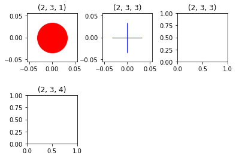

```python
plt.subplots_adjust(hspace=0.7, wspace=0.5)

plt.subplot(2, 3, 1)
plt.title("(2, 3, 1)")
plt.plot(0,0, 'ro', ms=50)

plt.subplot(2, 3, 2)
plt.title("(2, 3, 3)")
plt.plot(0,0, 'b+', ms=50)

plt.subplot(2, 3, 3)
plt.title("(2, 3, 3)")

plt.subplot(2, 3, 4)
plt.title("(2, 3, 4)");
```

Enumerate:

```python
rng = np.random.default_rng()

x = rng.integers(0,100, 10)
x
```

```
array([61, 26, 35, 44, 43, 46, 25,  9, 25, 88])
```

```python
list(enumerate(x))
```

```
[(0, 61),
 (1, 26),
 (2, 35),
 (3, 44),
 (4, 43),
 (5, 46),
 (6, 25),
 (7, 9),
 (8, 25),
 (9, 88)]
```

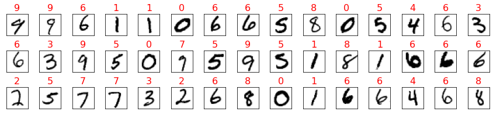

```python
rows = 3
cols = 15
plt.figure(figsize=(cols, rows))
plt.subplots_adjust(hspace=0.7)
for i, n in enumerate(rng.integers(0, 60000, rows*cols)):
    plt.subplot(rows, cols, i+1)
    plt.xticks([])
    plt.yticks([])
    plt.imshow(images[n].reshape(28,28), cmap="gray_r")
    plt.title(labels[n], c='r', fontdict={"fontsize": 16})
plt.show()
```

## k-NN

- Start with training data.
- Given a new data point $x$ compute its distance to each training data point.
- Select $k$ nearest neighbors of $x$ in the training data and check their labels.
- The label which appears most often is assigned to the point $x$ (decide what to do with ties).

Distance:

- Euclidean
- $L_p$ (in particular $L_1$)
- No need to compute roots while working with $L_p$ distances.
- Split images and labels into a training data set and test data set.
- Use about 10,000 numbers for training (the code may run slow if there will be too many), about 500-1000 for testing.

## 2-dimensional sample data

Create blobs using sklearn:

```python
from sklearn.datasets import make_blobs
import matplotlib.pyplot as plt
import numpy as np

X, y = make_blobs(n_samples=10,
                  n_features=2,
                  centers=4,
                  cluster_std=1,
                  random_state=1)
X, y
```

```
(array([[ -7.23731039,  -9.03108652],
        [ -8.86394306,  -5.05323981],
        [ -7.37541495,  -1.94406175],
        [ -5.37320505,  -2.58629112],
        [  0.08525186,   3.64528297],
        [-10.32012971,  -4.3374029 ],
        [ -0.79415228,   2.10495117],
        [ -7.02266844,  -7.57041289],
        [ -1.34052081,   4.15711949],
        [ -8.53560457,  -6.01348926]]),
 array([2, 1, 3, 3, 0, 1, 0, 2, 0, 1]))
```

Plot blobs:

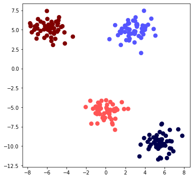

```python
X, y = make_blobs(n_samples=200,
                  n_features=2,
                  centers=4,
                  cluster_std=1,
                  random_state=10)

plt.figure(figsize=(6, 6))
plt.scatter(X[:, 0], X[:, 1], c=y, s=60, cmap="seismic");
```

Sidenote: matplotlib styles

```python
plt.style.available
```

```
['Solarize_Light2',
 '_classic_test_patch',
 '_mpl-gallery',
 '_mpl-gallery-nogrid',
 'bmh',
 'classic',
 'dark_background',
 'fast',
 'fivethirtyeight',
 'ggplot',
 'grayscale',
 'seaborn',
 'seaborn-bright',
 'seaborn-colorblind',
 'seaborn-dark',
 'seaborn-dark-palette',
 'seaborn-darkgrid',
 'seaborn-deep',
 'seaborn-muted',
 'seaborn-notebook',
 'seaborn-paper',
 'seaborn-pastel',
 'seaborn-poster',
 'seaborn-talk',
 'seaborn-ticks',
 'seaborn-white',
 'seaborn-whitegrid',
 'tableau-colorblind10']
```

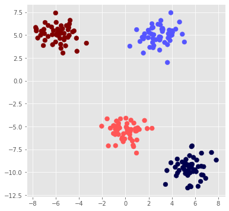

```python
plt.figure(figsize=(6, 6))
plt.style.use('ggplot')
plt.scatter(X[:, 0], X[:, 1], c=y, s=60, cmap="seismic");
```

From the course website:

```python
%config InlineBackend.figure_format = 'retina'
import matplotlib.pyplot as plt
from matplotlib.colors import ListedColormap, Normalize


def plot_clusters(X, y, p=None, p_label=None, neighbors=None):
    """
    Plots nearest neighbors of a given point.

    X:
        A 2-dimensional numpy array with coordinates
        of points in clusters
    y:
        A 1-dimensional numpy array with labels of points
    p:
        An array with coordinates of the point whose
        neighbors will be plotted.
    p_label:
        The predicted label of the point p.
    neighbors:
        A list of row numbers of X which are the nearest
        neighbors of the point p.
    """

    # build a custom colormap
    col_list = ['dodgerblue', 'limegreen', 'red', 'orange', 'fuchsia']
    colors = ListedColormap(col_list)
    norm = Normalize(0, len(col_list))

    plt.figure(figsize=(8, 8))
    with plt.style.context('seaborn'):
        scatter = plt.scatter(X[:, 0],
                              X[:, 1],
                              c=y,
                              s=90,
                              cmap=colors,
                              norm=norm,
                              label=y)
        if p is not None:
            p_col = "k" if p_label is None else colors(norm(p_label))
            plt.plot(p[0], p[1], marker="*", mfc=p_col, mec="k", ms=30, mew=2)
        if neighbors is not None:
            plt.scatter(X[neighbors, 0],
                        X[neighbors, 1],
                        edgecolors='black',
                        linewidth=3,
                        facecolors="None",
                        s=300)
        plt.legend(*scatter.legend_elements(),
                   markerscale=1.5,
                   prop={
                       "size": 12,
                       "weight": "normal"
                   })
    plt.show()
```

Plot blobs:

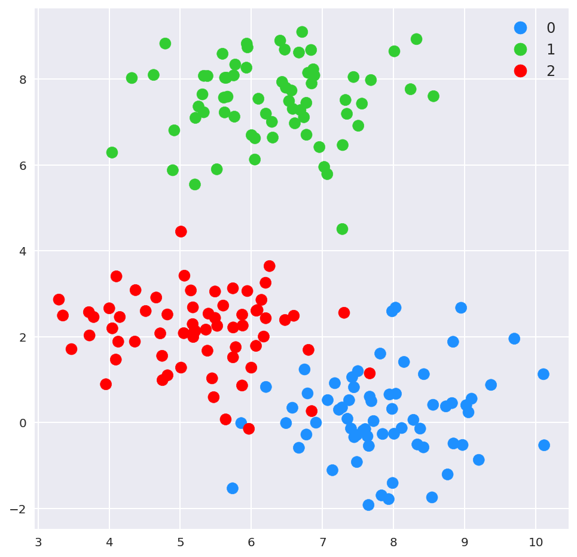

```python
from sklearn.datasets import make_blobs
X, y = make_blobs(n_samples=200,
                  n_features=2,
                  centers=3,
                  center_box=(0, 10),
                  cluster_std=1,
                  random_state=10)

plot_clusters(X, y)
```

Plot a point, its predicted label, and it nearest neighbors:

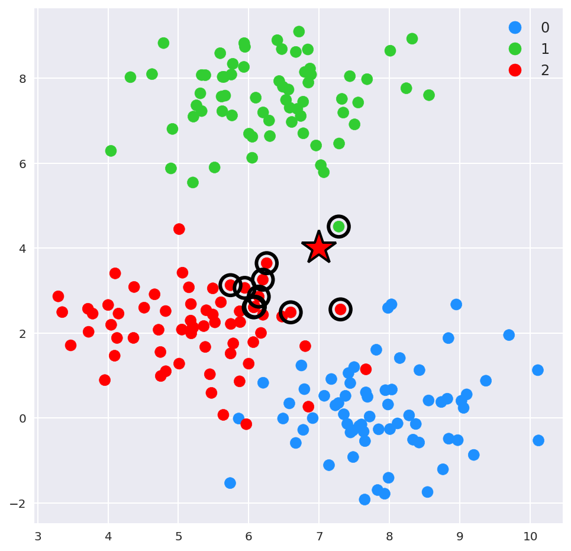

```python
p = [7, 4]
p_label = 2
neighbors = [103, 109, 24, 164, 131, 82, 122, 7, 21, 80]
plot_clusters(X, y, p, p_label, neighbors)
```

## Training and test data

Permute images and their labels:

```python
rng = np.random.default_rng(2)
rng.permutation(10)
```

```
array([2, 0, 7, 6, 9, 5, 3, 4, 8, 1])
```

```python
# permute data
rng = np.random.default_rng(2)
reorder = rng.permutation(len(images))
images = images[reorder]
labels = labels[reorder]
```

Then we can select training and test data:

```python
train_num = 10000
test_num = 1000

train_images = images[:train_num]
train_labels = labels[:train_num]

test_images = images[train_num: train_num + test_num]
test_labels = labels[train_num: train_num + test_num]
```

## Confusion matrix

Useful for representing accuracy of prediction. Rows correspond to actual labels, columns to the predicted labels. The value in a given row and column shows how many data points with the actual label corresponding to the row were predicted to have the label corresponding to the column.

```python
rng = np.random.default_rng(0)
c = rng.integers(0, 100, 100).reshape(10,10)
c
```

```
array([[85, 63, 51, 26, 30,  4,  7,  1, 17, 81],
       [64, 91, 50, 60, 97, 72, 63, 54, 55, 93],
       [27, 81, 67,  0, 39, 85, 55,  3, 76, 72],
       [84, 17,  8, 86,  2, 54,  8, 29, 48, 42],
       [40,  2,  0, 12,  0, 67, 52, 64, 25, 61],
       [76, 38, 46, 99, 80, 98, 37, 68, 95, 65],
       [84, 68, 70, 38, 87, 13, 57, 72, 84, 52],
       [37, 31, 42, 48, 71, 88,  7, 93, 53, 35],
       [67, 57, 25, 32, 71, 59, 50, 33, 76, 39],
       [32, 89, 26, 22, 71, 62,  4,  8, 37, 83]])
```

Plot the confusion matrix:

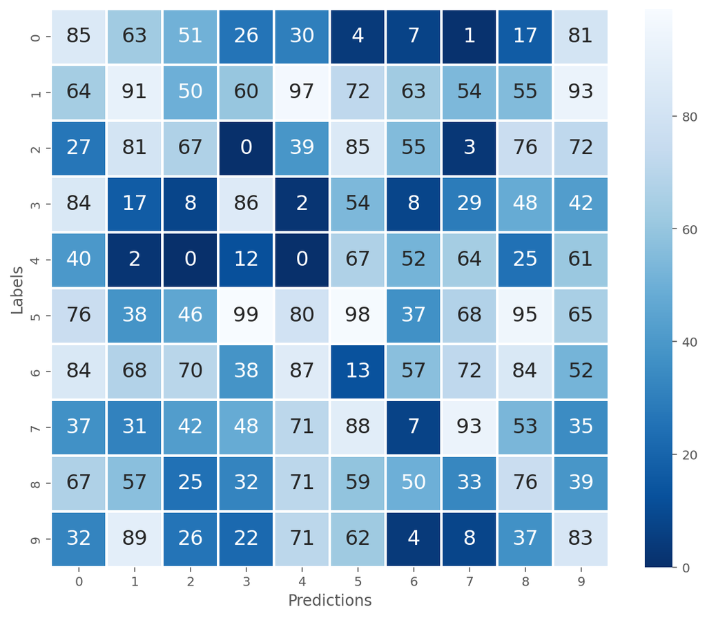

```python
import seaborn as sns
plt.figure(figsize=(10, 8))
sns.heatmap(c,
            cmap="Blues_r",
            annot=True,
            annot_kws={"fontsize": 16},
            cbar=True,
            linewidth=2,
            square=True
           )

plt.xlabel("Predictions")
plt.ylabel("Labels")
plt.show()
```

## Writing project reports

- Exprectations
- What to do and what to avoid
- Rubrics